# Homework Assignment 1

Wesley Chiu

Assigned: Oct 24, 2020, Due Sun Nov 01, 2020 11:59PM

## HW-1 Instructions

> Our class emphasizes clear communication of data analysis results to non-technical audiences. I expect your HTML output documents to be readable and well formatted. I expect you to put ample comments in your R code to make the code understandable. Along with accuracy of results, I am looking for quality of presentation as well. This homework is due by **11:59PM on Nov 01st**. To complete this assignment, follow these steps:
1. Create a new RStudio Project for this HW. Sync the project directory with a GitHub Repository (see instructions on Canvas on how to do that).
2. Download the `HW1.Rmd` file from Canvas. Save the file in the RStudio Project Directory.
3. Open `HW1.Rmd` in RStudio. Replace the “Your Name Here” text in the `author:` field with your name.
4. Supply your solutions to the homework by editing `HW1.Rmd`.
5. Run your code in the Console and Knit HTML frequently to check for errors.
6. You may find it easier to solve a problem by interacting only with the Console at first.
7. When you have completed the homework please check that your knits correctly when you click `Knit HTML`.
8. “Push” all your local changes to the GitHub Repo for the project.
9. Submit your RMD file, the HTML output and a link to your GitHub Repo on Canvas.

## Data frame basics

We will continue working with the nycflights dataset we looked at in class. **Please be sure to keep the data file in the same directory as the RMD file - your project directory.**

First - make sure that you are reading the data correctly and doing all the data cleaning steps that we did in class. Feel free to go beyond our class work in cleaning the data if you feel the need.

#### Import and Clean Data

```r
# Read in data
nyc <- read.csv("nycflights.csv")
# Look at what needs to be cleaned
str(nyc)
```

```
## 'data.frame':    336776 obs. of  20 variables:
##  $ X             : int  1 2 3 4 5 6 7 8 9 10 ...
##  $ year          : int  2013 2013 2013 2013 2013 2013 2013 2013 2013 2013 ...
##  $ month         : int  1 1 1 1 1 1 1 1 1 1 ...
##  $ day           : int  1 1 1 1 1 1 1 1 1 1 ...
##  $ dep_time      : int  517 533 542 544 554 554 555 557 557 558 ...
##  $ sched_dep_time: int  515 529 540 545 600 558 600 600 600 600 ...
##  $ dep_delay     : int  2 4 2 -1 -6 -4 -5 -3 -3 -2 ...
##  $ arr_time      : int  830 850 923 1004 812 740 913 709 838 753 ...
##  $ sched_arr_time: int  819 830 850 1022 837 728 854 723 846 745 ...
##  $ arr_delay     : int  11 20 33 -18 -25 12 19 -14 -8 8 ...
##  $ carrier       : chr  "UA" "UA" "AA" "B6" ...
##  $ flight        : int  1545 1714 1141 725 461 1696 507 5708 79 301 ...
##  $ tailnum       : chr  "N14228" "N24211" "N619AA" "N804JB" ...
##  $ origin        : chr  "EWR" "LGA" "JFK" "JFK" ...
##  $ dest          : chr  "IAH" "IAH" "MIA" "BQN" ...
##  $ air_time      : int  227 227 160 183 116 150 158 53 140 138 ...
##  $ distance      : int  1400 1416 1089 1576 762 719 1065 229 944 733 ...
##  $ hour          : int  5 5 5 5 6 5 6 6 6 6 ...
##  $ minute        : int  15 29 40 45 0 58 0 0 0 0 ...
##  $ time_hour     : chr  "2013-01-01 05:00:00" "2013-01-01 05:00:00" "2013-01-01 05:00:00" "2013-01-01 05:00:00" ...
```

```r
# Clean data
nyc$X <- NULL
nyc$carrier <- as.factor(nyc$carrier)
nyc$flight <- as.factor(nyc$flight)
nyc$tailnum <- as.factor(nyc$tailnum)
nyc$origin <- as.factor(nyc$origin)
nyc$dest <- as.factor(nyc$dest)
```

I now would like you to answer the following - all in their own separate R code blocks.

### Data Exploration

Let’s first do some simple exploration of this data. I would like for you to answer each of the questions below with an **inline R code** integrated into the text and not in a separate R code block.

- How many airlines are there? (Hint: `levels` and `length` can be useful here)

There are 16 airlines.

- How many flights there were by the airline with code `OO`? (Hint: `nrow` can be useful here along with logical indexing)

There are 32 flights by the airline with code ‘00’.

- How long is the shortest flight out of any NYC airport? (Hint: `min` can be useful, remember to handle `NA` values)

The shortest flight in distance out of any NYC airport is 17.

- How many flights where there by United Airlines (code: UA) on Jan 12th 2013?

There are 112 flights by United Airlines on Jan 12th, 2013.

### Arrival Delay

Lets focus on Arrival Delay.

- What was the average arrival delay for all airports and all airlines combined in Jan 2013?

```r
mean(nyc[nyc$month == "1" & nyc$year == "2013", ]$arr_delay, na.rm = TRUE)
```

```
## [1] 6.129972
```

```r
# Answer in minutes, first indexed the data so it only considers flights during Jan 2013, then took the mean of arr_delay.
```

- Whats was the median arrival delay for all airports and all airlines combined in Jan 2013?

```r
median(nyc[nyc$month == "1" & nyc$year == "2013", ]$arr_delay, na.rm = TRUE)
```

```
## [1] -3
```

```r
# Answer in minutes, first indexed the data so it only considers flights during Jan 2013, then took the median of arr_delay.
```

Based on your answers to the two questions above, what can you say about the distribution of arrival delays? Provide your answer in a text paragraph form.

The mean is larger than the median, which means that there are larger outliers on the positive side of the distribution than there are on the negative side. The distribution is right skewed, and since the median is negative, we can say that less than half of all flights in Jan 2013 were delayed, but there were also a few extremely long delays.

### Airline Performance

Lets see if all airlines are equally terrible as far as flight arrival delays are concerned. For this question you will have to make sure that airline column is coded as a factor.

- Calculate average arrival delays by airline (Hint: look up the command `tapply`)

```r
# Average arrival delays using tapply, put into a variable for use later.

arr_delay_by_airline <- tapply(nyc$arr_delay, nyc$carrier, mean, na.rm = TRUE)

arr_delay_by_airline
```

```
##         9E         AA         AS         B6         DL         EV         F9
##  7.3796692  0.3642909 -9.9308886  9.4579733  1.6443409 15.7964311 21.9207048
##         FL         HA         MQ         OO         UA         US         VX
## 20.1159055 -6.9152047 10.7747334 11.9310345  3.5580111  2.1295951  1.7644644
##         WN         YV
##  9.6491199 15.5569853
```

- Draw a Bar Plot of Average Arrival Delays for all the Airlines (Hint: command for making a Bar Plot is simply `barplot`)

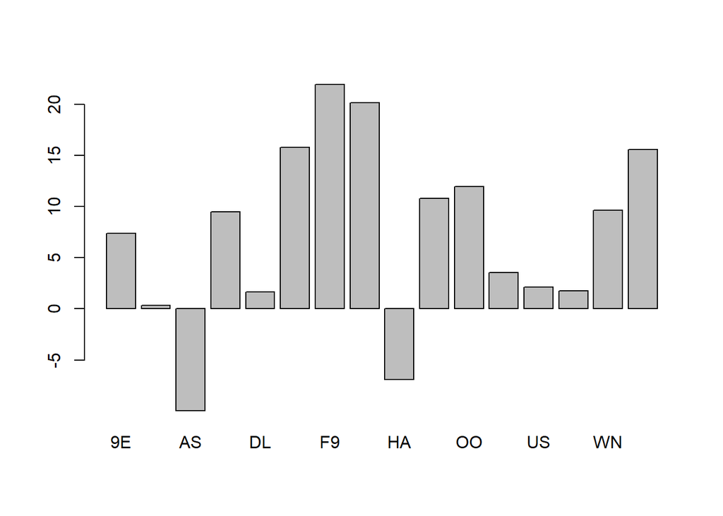

```r
# Bar Plot of the previous measure

barplot(arr_delay_by_airline)
```

- Which airline has the highest average arrival delay? Which airline has the smallest average arrival delay? Are there airlines that actually have negative average delay? Provide answer to this question in a text paragraph form using **inline R code**.

The airline with the highest average arrival delay is: F9

The airline with the smallest average arrival delay is: AS

Airlines that have negative average delay are: AS, HA

### Air Gain

Create a new column named airgain such that airgain = (departure delay - arrival delay) : this is the amount of delay a flight made up while in air.

```r
# Create airgain column

nyc$airgain <- nyc$dep_delay - nyc$arr_delay
```

1. Explore airgain data - calculate suitable descriptive statistics and appropriate graphics to better understand this data. This part is open ended - you do what you feel works best for you.

```r
# Take a look at airgain numbers
summary(nyc$airgain)
```

```
##    Min. 1st Qu.  Median    Mean 3rd Qu.    Max.    NA's
## -196.00   -3.00    7.00    5.66   17.00  109.00    9430
```

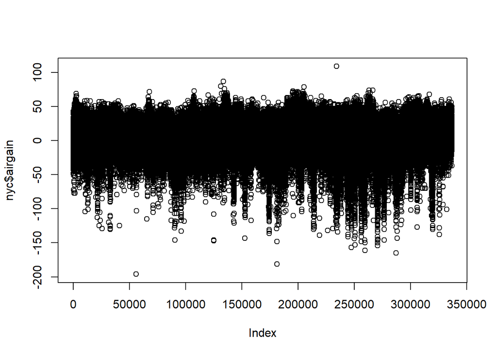

```r
plot(nyc$airgain)
```

2. Answer the questions:
- do airlines actually gain any time when in air on average?

Average airgain is 5.6597789, which is positive, so airlines do gain time when in air on average.

- Calculate average airgain for different airlines - which airlines do a better job, which do a worse job?

```r
# Average airgain by airline

avgag <- tapply(nyc$airgain, nyc$carrier, mean, na.rm = TRUE) # saved into a variable for use later in the plot.
avgag
```

```
##         9E         AA         AS         B6         DL         EV         F9
##  9.0599052  8.2048393 15.7616361  3.5095746  7.5796089  4.0424982 -1.7195301
##         FL         HA         MQ         OO         UA         US         VX
## -1.5099213 11.8157895 -0.3293526  0.6551724  8.4588972  1.6150976 10.9921814
##         WN         YV
##  8.0125374  3.3419118
```

Most airlines do a good job of making up some time while in the air, with AS, HA, and VX doing the best. There are some airlines that have negative airgain, which means they lose time in the air, and they are F9, FL, and MQ.

- Build a graphic of average airgain for different airlines sorted by airgain. We want to graphically visualize which airlines are good at “catching up” when in air and which airlines actually lose time further after taking off.

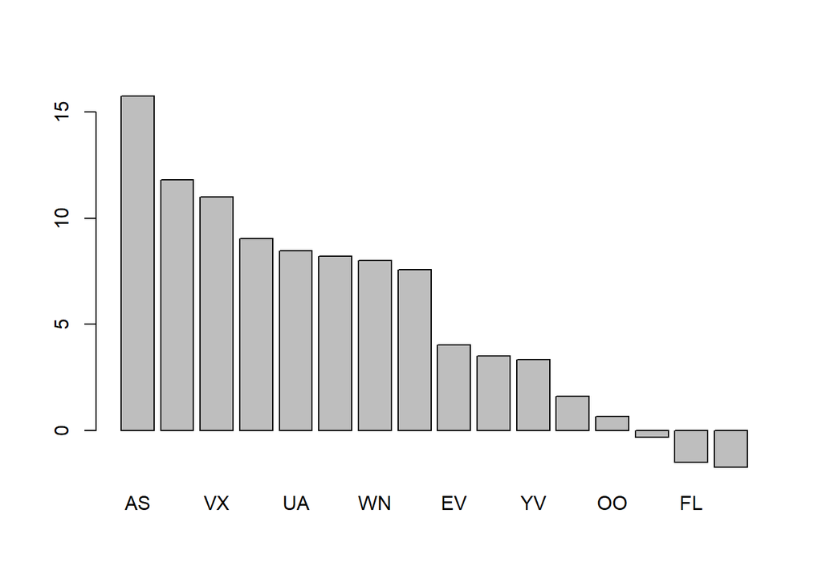

```r
barplot(sort(avgag, decreasing = TRUE)) # Sorted plot to have a better visual.
```

That’s it. Once you are done, make sure everything works and knits well and then you can push your changes to the GitHub repo and uplaod the RMD flile and the html output to Canvas.

**Have Fun!**

Sanjeev